# Análise Final La Msion Brasil

## Bibliotecas

```python
import pandas as pd
import numpy as np

import seaborn as sns
import matplotlib.pyplot as plt

from sklearn.preprocessing import StandardScaler
from sklearn.cluster import KMeans
from sklearn.model_selection import train_test_split
from sklearn.linear_model import LinearRegression
from sklearn.metrics import r2_score, mean_absolute_error
from statsmodels.stats.multicomp import pairwise_tukeyhsd
from sklearn.decomposition import PCA
import pingouin as pg
# from statsmodels.stats.outliers_influence import variance_inflation_factor

from scipy import stats
import statsmodels.api as sm
from statsmodels.formula.api import ols
import scikit_posthocs as sp
```

```python
# Define que o pandas não deve limitar o número de colunas exibidas
pd.set_option("display.max_columns", None)

# BÔNUS: Você também pode fazer o mesmo para as linhas
pd.set_option("display.max_rows", None)

# BÔNUS: E aumentar a largura da exibição para evitar quebras de linha
pd.set_option("display.width", 1000)
```

```python
# --- Bloco de Estilo para TCC (Colocar no início do seu código) ---

# Define o tema do Seaborn
sns.set_theme(
    style="whitegrid",  # Estilo com fundo branco e grades cinzas claras e sutis.
    # Outras opções ótimas: 'white' (sem grades) ou 'ticks' (com marcações nos eixos).
    context="paper",  # Contexto que otimiza os tamanhos de fonte e linhas para artigos/publicações.
    palette="colorblind",  # Paleta de cores sóbria e acessível.
)

# Configurações adicionais com Matplotlib (opcional, mas recomendado)
plt.rcParams["font.family"] = (
    "serif"  # Usa uma fonte com serifa, que é mais clássica em textos acadêmicos.
)
plt.rcParams["figure.figsize"] = (
    10,
    5,
)  # Define um tamanho padrão para as figuras (largura, altura em polegadas).
plt.rcParams["axes.spines.top"] = False  # Remove a linha (espinha) de cima do gráfico.
plt.rcParams["axes.spines.right"] = (
    False  # Remove a linha (espinha) da direita do gráfico.
)

# --------------------------------------------------------------------
```

## Carregando os dados

```python
df_segundos = pd.read_csv("Dados/df_selecionado_segundos.csv", sep=";")
df_segundos.set_index("Nome Atleta", inplace=True)
df_segundos.head()
```

| Nome Atleta | Unnamed: 0 | sexo | faixa_etaria | peso | Tempo_Final_seg | Ritmo_Medio_seg | Variabilidade_Ritmo_std | Variabilidade_Ritmo_min_std | Ritmo_Medio_Primeira_Metade | Ritmo_Medio_Segunda_Metade | Tempo_Total_Primeira_Metade | Tempo_Total_Segunda_Metade | Diferenca_Media_Seg_Menos_Pri | Diferenca_total_Seg_Menos_Pri | diff_relativa_segunda_primeira_parte | Ritmo_Medio_Trecho_0-5_km | Ritmo_Medio_Trecho_5-10_km | Ritmo_Medio_Trecho_10-15_km | Ritmo_Medio_Trecho_15-20_km | Ritmo_Medio_Trecho_20-25_km | Ritmo_Medio_Trecho_25-30_km | Ritmo_Medio_Trecho_30-35_km | Ritmo_Medio_Trecho_35-40_km | Tempo_Total_Trecho_0-5_km | Tempo_Total_Trecho_5-10_km | Tempo_Total_Trecho_10-15_km | Tempo_Total_Trecho_15-20_km | Tempo_Total_Trecho_20-25_km | Tempo_Total_Trecho_25-30_km | … |
| --- | --- | --- | --- | --- | --- | --- | --- | --- | --- | --- | --- | --- | --- | --- | --- | --- | --- | --- | --- | --- | --- | --- | --- | --- | --- | --- | --- | --- | --- | --- |
| ALFREDO GUIMARAES | 0 | Homens | 45 a 54 | 75 a 84 kg | 21774 | 604.833333 | 290.291331 | 4.838189 | 667.777778 | 541.888889 | 12020 | 9754 | -2.10 | -37.76 | -0.19 | 419.0 | 600.0 | 634.8 | 983.0 | 495.4 | 539.8 | 611.4 | 357.0 | 2095.0 | 3000.0 | 3174.0 | 4915.0 | 2477.0 | 2699.0 | … |
| Albert Melo | 1 | Homens | 25 a 34 | 75 a 84 kg | 31986 | 888.500000 | 417.596832 | 6.959947 | 942.944444 | 834.055556 | 16973 | 15013 | -1.82 | -32.66 | -0.12 | 599.8 | 898.8 | 825.4 | 1442.8 | 737.4 | 825.0 | 927.8 | 701.0 | 2999.0 | 4494.0 | 4127.0 | 7214.0 | 3687.0 | 4125.0 | … |
| Alessandro Sousa(allê) | 2 | Homens | 45 a 54 | 65 a 74 kg | 33826 | 939.611111 | 669.719569 | 11.161993 | 945.388889 | 933.833333 | 17017 | 16809 | -0.20 | -3.47 | -0.01 | 508.2 | 694.2 | 748.0 | 2026.4 | 1284.6 | 717.6 | 732.0 | 271.0 | 2541.0 | 3471.0 | 3740.0 | 10132.0 | 6423.0 | 3588.0 | … |
| Alex Junior Aj | 3 | Homens | 20 a 24 | 65 a 74 kg | 18496 | 513.777778 | 261.647539 | 4.360792 | 598.944444 | 428.611111 | 10781 | 7715 | -2.84 | -51.10 | -0.28 | 366.2 | 532.2 | 568.6 | 869.4 | 404.2 | 445.6 | 478.2 | 174.0 | 1831.0 | 2661.0 | 2843.0 | 4347.0 | 2021.0 | 2228.0 | … |
| Alexandre Santiago | 4 | Homens | 35 a 44 | 55 a 64 kg | 14626 | 417.885714 | 195.390826 | 3.256514 | 467.722222 | 365.117647 | 8419 | 6207 | -1.71 | -36.87 | -0.22 | 316.6 | 413.0 | 448.6 | 658.6 | 313.8 | 373.0 | 401.6 | NaN | 1583.0 | 2065.0 | 2243.0 | 3293.0 | 1569.0 | 1865.0 | … |

```python
df_segundos.columns
```

```
Index(['Unnamed: 0', 'sexo', 'faixa_etaria', 'peso', 'Tempo_Final_seg', 'Ritmo_Medio_seg', 'Variabilidade_Ritmo_std', 'Variabilidade_Ritmo_min_std', 'Ritmo_Medio_Primeira_Metade', 'Ritmo_Medio_Segunda_Metade', 'Tempo_Total_Primeira_Metade', 'Tempo_Total_Segunda_Metade', 'Diferenca_Media_Seg_Menos_Pr…
       'Tempo_Total_PLANO', 'Tempo_Total_SUBIDA', 'indice_subida', 'indice_descida_vs_subida', 'indice_descida'],
      dtype='object')
```

## Verificação da Correlação

```python
# 1.1. Selecionar as variáveis numéricas de interesse
vars_numericas = [
    "Tempo_Final_seg",
    "Variabilidade_Ritmo_std",
    "diff_relativa_segunda_primeira_parte",
    "indice_subida",
    "indice_descida",
]
df_selecionado = df_segundos[vars_numericas]

# 1.2. Calcular a matriz de correlação
# O método .corr() em pandas já ignora valores ausentes por padrão (similar a use = "complete.obs")
cor_matrix = df_selecionado.corr()

# 1.3. Imprimir a matriz de correlação arredondada
print("--- Matriz de Correlação Inicial ---")
print(round(cor_matrix, 3))
print("\n")  # Adiciona uma linha em branco para melhor visualização
```

```
--- Matriz de Correlação Inicial ---
                                      Tempo_Final_seg  Variabilidade_Ritmo_std  diff_relativa_segunda_primeira_parte  indice_subida  indice_descida
Tempo_Final_seg                                 1.000                    0.954                                 0.340          0.439          -0.457
Variabilidade_Ritmo_std                         0.954                    1.000                                 0.265          0.527          -0.554
diff_relativa_segunda_primeira_parte            0.340                    0.265                                 1.000          0.050           0.105
indice_subida                                   0.439                    0.527                                 0.050          1.000          -0.884
indice_descida                                 -0.457                   -0.554                                 0.105         -0.884           1.000
```

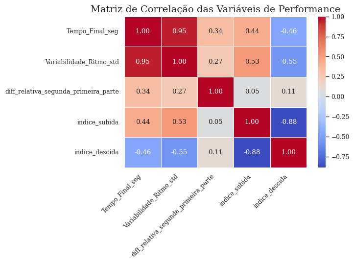

```python
# 1.4. Visualização gráfica da matriz de correlação (equivalente ao corrplot)
plt.figure(figsize=(6, 4))
sns.heatmap(cor_matrix, annot=True, cmap="coolwarm", fmt=".2f", linewidths=0.5)
plt.title("Matriz de Correlação das Variáveis de Performance", fontsize=14)
plt.xticks(rotation=45, ha="right")
plt.yticks(rotation=0)
plt.show()
```

A análise exploratória inicial, por meio da matriz de correlação de Pearson, revelou associações lineares significativas entre as variáveis de performance dos corredores. Os principais achados foram:

- Forte Correlação Positiva:

Tempo_Final_seg e Variabilidade_Ritmo_std (r≈0.95): Indica que corredores mais lentos (maior tempo final) também apresentam uma maior oscilação em seu ritmo ao longo da prova. Isso sugere que a consistência do ritmo é um fator chave para um bom desempenho.

- Correlações Moderadas:

Tempo_Final_seg tem correlação positiva moderada com indice_subida (r≈0.44) e negativa moderada com indice_descida (r≈−0.46). Isso significa que corredores mais lentos tendem a ser desproporcionalmente mais penalizados em subidas e a aproveitar menos as descidas.

- Identificação de Multicolinearidade:

A observação mais crítica foi a forte correlação negativa entre indice_subida e indice_descida (r=−0.884). Este valor indica um alto grau de multicolinearidade. Estatisticamente, isso implica que as duas variáveis são amplamente redundantes, pois uma pode ser linearmente prevista a partir da outra.

### Trasformação Ortogonal

**Justificativa da Transformação de Variáveis**

A presença de multicolinearidade pode prejudicar a performance e a interpretabilidade de modelos estatísticos, especialmente algoritmos baseados em distância como o K-Means. Para mitigar este efeito, optou-se por uma transformação ortogonal sobre as variáveis indice_subida (S) e indice_descida (D). Esta abordagem, análoga a uma Análise de Componentes Principais (PCA) simplificada, gera um novo conjunto de variáveis não correlacionadas, preservando a informação original.

```python
# Transformação Ortogonal para Tratar a Multicolinearidade ---

# Criar as novas variáveis a partir de 'indice_subida' (S) e 'indice_descida' (D)
S = df_segundos["indice_subida"]
D = df_segundos["indice_descida"]

# A transformação cria duas novas variáveis independentes
df_segundos["indice_especializacao"] = (D - S) / np.sqrt(2)
df_segundos["indice_capacidade_geral"] = (D + S) / np.sqrt(2)
```

A transformação resultou em duas novas features independentes com interpretação direta sobre o perfil do corredor em relação ao terreno:

- **indice_capacidade_geral:**

> **O que mede**: A performance combinada do atleta em terrenos com variação de altimetria. Captura a capacidade do corredor de lidar tanto com subidas quanto com descidas.

**Interpretação:**

> **Valores altos**: Indicam um corredor "completo" ou "generalista", que é eficiente tanto para subir quanto para descer.

> **Valores baixos**: Sugerem um corredor com dificuldades gerais em terrenos variados, sendo muito penalizado em subidas e não conseguindo compensar em descidas.
- **indice_especializacao:**

> **O que mede**: O viés de performance do atleta para um tipo específico de terreno.

**Interpretação:**

> **Valores positivos** (próximos de 1 ou mais): Indicam um corredor "especialista em descidas" (downhill specialist), que é muito mais rápido em descidas do que lento em subidas.

> **Valores negativos** (próximos de -1 ou menos): Indicam um "especialista em subidas" (climber), que, embora perca tempo subindo, perde proporcionalmente menos tempo do que ganha nas descidas.

> **Valores próximos de zero**: Caracterizam um corredor "equilibrado", cujo desempenho em subidas e descidas é simétrico.

```python
#  Selecionar as variáveis originais e as transformadas
vars_verificacao = [
    "Tempo_Final_seg",
    "indice_subida",
    "indice_descida",
    "indice_capacidade_geral",
    "indice_especializacao",
]

# 3.2. Calcular e imprimir a nova matriz de correlação
cor_matrix_transformada = df_segundos[vars_verificacao].corr()
print("--- Matriz de Correlação Após a Transformação ---")
print(round(cor_matrix_transformada, 3))
print("\n")

# 3.3. Verificar especificamente a correlação entre os novos índices
cor_novos_indices = df_segundos["indice_capacidade_geral"].corr(
    df_segundos["indice_especializacao"]
)
print(
    f"Correlação entre 'indice_capacidade_geral' e 'indice_especializacao': {cor_novos_indices:.7f}"
)
```

```
--- Matriz de Correlação Após a Transformação ---
                         Tempo_Final_seg  indice_subida  indice_descida  indice_capacidade_geral  indice_especializacao
Tempo_Final_seg                    1.000          0.439          -0.457                   -0.014                 -0.462
indice_subida                      0.439          1.000          -0.884                    0.292                 -0.971
indice_descida                    -0.457         -0.884           1.000                    0.189                  0.970
indice_capacidade_geral           -0.014          0.292           0.189                    1.000                 -0.057
indice_especializacao             -0.462         -0.971           0.970                   -0.057                  1.000


Correlação entre 'indice_capacidade_geral' e 'indice_especializacao': -0.0565072
```

**Validação da Técnica**

A eficácia da transformação foi confirmada ao se calcular a correlação entre as novas variáveis, que resultou em r≈−0.057. Este valor, muito próximo de zero, valida a ortogonalidade dos novos eixos e confirma que o problema da multicolinearidade foi efetivamente solucionado. As variáveis indice_capacidade_geral e indice_especializacao estão, portanto, aptas para serem utilizadas em etapas subsequentes de modelagem, como a análise de clusters.

## Clusterização

```python
features_para_cluster = [
    "diff_relativa_segunda_primeira_parte",
    "Variabilidade_Ritmo_std",
    "indice_capacidade_geral",
    "indice_especializacao",
]

# Criando um novo DataFrame apenas com as features selecionadas e sem dados faltantes
df_cluster = df_segundos[features_para_cluster].dropna()

# Guardando os nomes dos atletas (o índice) para usarmos depois
nomes_atletas = df_cluster.index

# --- 2. ESCALONAMENTO DOS DADOS (PASSO OBRIGATÓRIO) ---
# Todas as variáveis precisam estar na mesma escala de importância
scaler = StandardScaler()
dados_escalonados = scaler.fit_transform(df_cluster)

print("Dados prontos e escalonados! Próximo passo: encontrar o número de clusters.")
```

```
Dados prontos e escalonados! Próximo passo: encontrar o número de clusters.
```

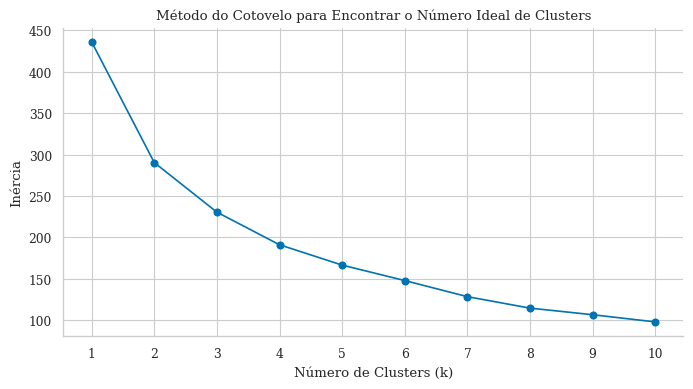

```python
# --- 3. MÉTODO DO COTOVELO ---
inercia = []
range_clusters = range(1, 11)  # Vamos testar de 1 a 10 clusters

for k in range_clusters:
    kmeans = KMeans(n_clusters=k, random_state=42, n_init=10)
    kmeans.fit(dados_escalonados)
    inercia.append(kmeans.inertia_)

# Plotando o gráfico do cotovelo
plt.figure(figsize=(8, 4))
plt.plot(range_clusters, inercia, marker="o")
plt.title("Método do Cotovelo para Encontrar o Número Ideal de Clusters")
plt.xlabel("Número de Clusters (k)")
plt.ylabel("Inércia")
plt.xticks(range_clusters)
plt.grid(True)
plt.show()
```

```
Iniciando a Análise de Silhueta para encontrar o k ideal...
Para k = 2, a pontuação de silhueta média é: 0.3344
Para k = 3, a pontuação de silhueta média é: 0.3410
Para k = 4, a pontuação de silhueta média é: 0.3100
Para k = 5, a pontuação de silhueta média é: 0.2615
Para k = 6, a pontuação de silhueta média é: 0.2587
Para k = 7, a pontuação de silhueta média é: 0.2436
Para k = 8, a pontuação de silhueta média é: 0.2838
Para k = 9, a pontuação de silhueta média é: 0.2736
Para k = 10, a pontuação de silhueta média é: 0.2628
--------------------------------------------------
Análise concluída. O melhor valor de k é 3 com uma pontuação de 0.3410.
--------------------------------------------------
```

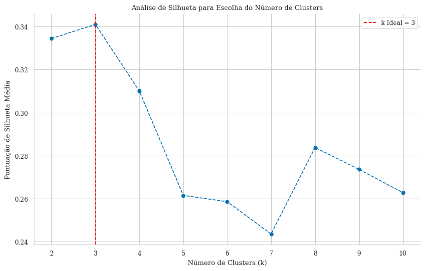

```python
from sklearn.metrics import silhouette_score

# 1. Definir o intervalo de clusters que queremos testar
intervalo_k = range(2, 11)  # Testaremos de 2 a 10 clusters
pontuacoes_silhueta = []

print("Iniciando a Análise de Silhueta para encontrar o k ideal...")

# 2. Loop para testar cada valor de k
for k in intervalo_k:
    # Criar e treinar o modelo K-Means para o k atual
    # n_init='auto' é a configuração padrão recomendada
    # random_state=42 garante que os resultados sejam sempre os mesmos
    kmeans_model = KMeans(n_clusters=k, n_init="auto", random_state=42)
    kmeans_model.fit(dados_escalonados)

    # Obter os rótulos de cluster para cada ponto de dado
    labels = kmeans_model.labels_

    # Calcular a pontuação de silhueta média e armazená-la
    pontuacao = silhouette_score(dados_escalonados, labels)
    pontuacoes_silhueta.append(pontuacao)

    print(f"Para k = {k}, a pontuação de silhueta média é: {pontuacao:.4f}")

# 3. Encontrar o valor de k que resultou na maior pontuação
k_ideal = intervalo_k[np.argmax(pontuacoes_silhueta)]
maior_pontuacao = max(pontuacoes_silhueta)

print("-" * 50)
print(
    f"Análise concluída. O melhor valor de k é {k_ideal} com uma pontuação de {maior_pontuacao:.4f}."
)
print("-" * 50)

# 4. Plotar o gráfico com os resultados
plt.figure(figsize=(10, 6))
plt.plot(intervalo_k, pontuacoes_silhueta, marker="o", linestyle="--")
plt.xlabel("Número de Clusters (k)")
plt.ylabel("Pontuação de Silhueta Média")
plt.title("Análise de Silhueta para Escolha do Número de Clusters")
plt.xticks(intervalo_k)
plt.grid(True)

# Adicionar uma linha vertical para destacar o k ideal no gráfico
plt.axvline(x=k_ideal, color="red", linestyle="--", label=f"k Ideal = {k_ideal}")
plt.legend()

plt.show()

# --------------------------------------------------------------------
# FIM DO CÓDIGO
# --------------------------------------------------------------------
```

Pelo método do cotovelo e da silhueta vamos definir 3 clusters

```python
# --- 4. RODANDO O MODELO FINAL ---
# Supondo que o número ideal de clusters que encontramos foi 3
numero_ideal_clusters = 3

kmeans = KMeans(n_clusters=numero_ideal_clusters, random_state=42, n_init=10)
kmeans_final = kmeans.fit(dados_escalonados)

# Adicionando os rótulos dos clusters de volta ao nosso DataFrame
df_cluster["cluster"] = kmeans_final.labels_


# --- 5. INTERPRETAÇÃO DOS CLUSTERS (PROFILING) ---
# Este é o passo mais importante: entender o que cada cluster significa.
# Vamos agrupar por cluster e calcular a média de cada variável.
perfis_clusters = df_cluster.groupby("cluster").mean().round(3)

print("--- Perfis dos Clusters Encontrados ---")
print(perfis_clusters)
```

```
--- Perfis dos Clusters Encontrados ---
         diff_relativa_segunda_primeira_parte  Variabilidade_Ritmo_std  indice_capacidade_geral  indice_especializacao
cluster
0                                      -0.174                  653.023                    0.018                 -0.314
1                                      -0.204                  286.063                    0.035                 -0.228
2                                      -0.070                  573.035                    0.054                 -0.328
```

```python
df_segundos["cluster"] = df_cluster["cluster"]


# --- Parte 2: Sumarização e Análise dos Perfis dos Clusters ---

# 2.1. Criar a tabela de resumo (equivalente ao group_by |> summarise)
# Usamos o dataframe com os valores originais (não escalados) para a interpretação
cluster_summary = (
    df_segundos.dropna(subset=["cluster"])
    .groupby("cluster")
    .agg(
        N=("cluster", "size"),
        Proporcao=(
            "cluster",
            lambda x: round(
                100 * x.size / len(df_segundos.dropna(subset=["cluster"])), 1
            ),
        ),
        Variabilidade_Media=("Variabilidade_Ritmo_std", lambda x: round(x.mean(), 2)),
        Estrategia_Media=(
            "diff_relativa_segunda_primeira_parte",
            lambda x: round(x.mean(), 3),
        ),
        Capacidade_Geral_Media=(
            "indice_capacidade_geral",
            lambda x: round(x.mean(), 3),
        ),
        Especializacao_Media=("indice_especializacao", lambda x: round(x.mean(), 3)),
        Tempo_Final_seg=("Tempo_Final_seg", lambda x: round(x.mean() / 60, 1)),
    )
    .sort_values(by="Tempo_Final_seg")
    .reset_index()
)

print("--- Resumo por Cluster ---")
print(cluster_summary)
print("\n")
```

```
--- Resumo por Cluster ---
   cluster   N  Proporcao  Variabilidade_Media  Estrategia_Media  Capacidade_Geral_Media  Especializacao_Media  Tempo_Final_seg
0        1  63       57.8               286.06            -0.204                   0.035                -0.228            342.8
1        2  27       24.8               573.03            -0.070                   0.054                -0.328            509.9
2        0  19       17.4               653.02            -0.174                   0.018                -0.314            559.6
```

**Perfis de Corredores: Uma Análise de Clusters** A aplicação do algoritmo K-Means com k=3 permitiu a segmentação da amostra em três grupos distintos e interpretáveis, ordenados por desempenho:

**Cluster 1: Os Elite (57.8% da amostra)**

**Cluster 2: Os Intermediários (24.8% da amostra)**

**Cluster 0: Os Amadores (17.4% da amostra)**

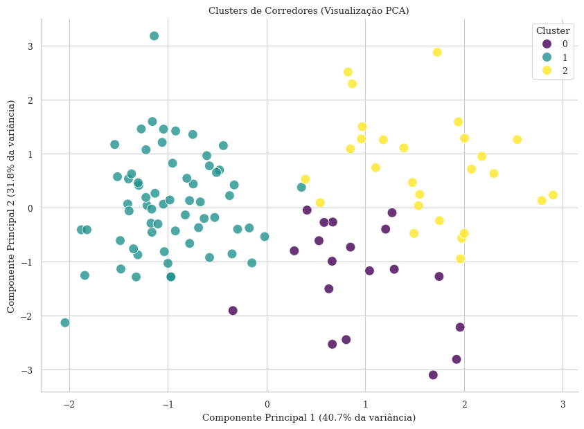

```python
pca = PCA(n_components=2)
principais_componentes = pca.fit_transform(dados_escalonados)
df_pca = pd.DataFrame(data=principais_componentes, columns=["PC1", "PC2"])
df_pca["cluster"] = kmeans_final.labels_

plt.figure(figsize=(10, 7))
sns.scatterplot(
    x="PC1", y="PC2", hue="cluster", data=df_pca, palette="viridis", s=100, alpha=0.8
)
plt.title("Clusters de Corredores (Visualização PCA)")
plt.xlabel(
    f"Componente Principal 1 ({pca.explained_variance_ratio_[0] * 100:.1f}% da variância)"
)
plt.ylabel(
    f"Componente Principal 2 ({pca.explained_variance_ratio_[1] * 100:.1f}% da variância)"
)
plt.legend(title="Cluster")
plt.grid(True)
plt.show()
```

**Visualização PCA**

Reduz a dimensionalidade das 4 variáveis usadas para apenas 2 "Componentes Principais", que são combinações lineares das originais e que capturam o máximo de variância possível (no seu caso, 72%). Isso permite visualizar os clusters num gráfico 2D. O objetivo é ver o quão "separados" e "coesos" os grupos são.

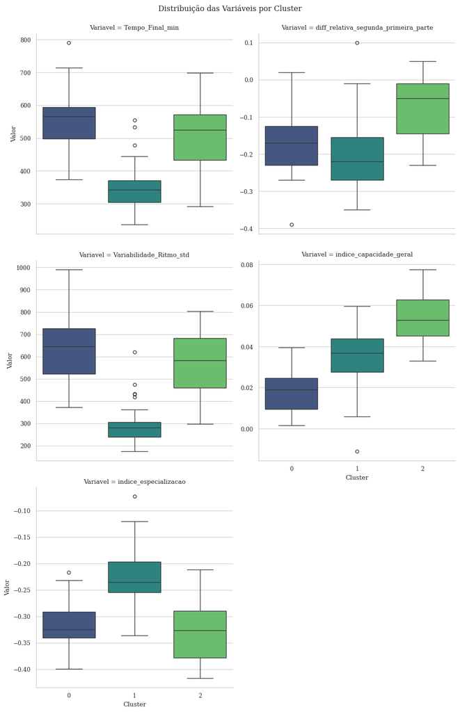

```python
df_boxplot = df_segundos.dropna(subset=["cluster"]).copy()
df_boxplot["Tempo_Final_min"] = df_boxplot["Tempo_Final_seg"] / 60
vars_para_boxplot = ["cluster", "Tempo_Final_min"] + features_para_cluster
df_melted = df_boxplot[vars_para_boxplot].melt(
    id_vars="cluster", var_name="Variavel", value_name="Valor"
)

# Criar o gráfico
g = sns.catplot(
    x="cluster",
    y="Valor",
    col="Variavel",
    data=df_melted,
    kind="box",
    col_wrap=2,
    palette="viridis",
    sharey=False,
)
g.fig.suptitle("Distribuição das Variáveis por Cluster", y=1.02)
g.set_axis_labels("Cluster", "Valor")
plt.show()
```

### Comparação entre os clusters

Após a segmentação dos corredores em três clusters, foi conduzida uma Análise de Variância (ANOVA) para validar estatisticamente se os perfis identificados diferem significativamente em relação a variáveis-chave de desempenho. O objetivo do teste é verificar se a variação observada nas médias das variáveis entre os clusters é significativamente maior do que a variação dentro de cada cluster.

**Passos Detalhados:**

- **Hipóteses:**

> **H₀:** As médias (ou distribuições) das variáveis de prova são iguais para todos os clusters.

> **H₁:** Pelo menos uma das médias (ou distribuições) das Variaveis de prova é diferente das demais.
- **Nível de Significância:** α = 0.05.

**Pressupostos**

- Testar a Homogeneidade de Variâncias (Levene)
- Testar a Normalidade dos Resíduos (Shapiro-Wilk)

#### Testar a Homogeneidade de Variâncias (Levene)

> H₀: As variâncias são iguais entre os grupos

Se p-valor < 0.05, o pressuposto é violado

```python
df_with_clusters = df_segundos.dropna(subset=["cluster"]).copy()
df_with_clusters["cluster"] = df_with_clusters["cluster"].astype(int)
df_with_clusters.head(2)
```

| Nome Atleta | Unnamed: 0 | sexo | faixa_etaria | peso | Tempo_Final_seg | Ritmo_Medio_seg | Variabilidade_Ritmo_std | Variabilidade_Ritmo_min_std | Ritmo_Medio_Primeira_Metade | Ritmo_Medio_Segunda_Metade | Tempo_Total_Primeira_Metade | Tempo_Total_Segunda_Metade | Diferenca_Media_Seg_Menos_Pri | Diferenca_total_Seg_Menos_Pri | diff_relativa_segunda_primeira_parte | Ritmo_Medio_Trecho_0-5_km | Ritmo_Medio_Trecho_5-10_km | Ritmo_Medio_Trecho_10-15_km | Ritmo_Medio_Trecho_15-20_km | Ritmo_Medio_Trecho_20-25_km | Ritmo_Medio_Trecho_25-30_km | Ritmo_Medio_Trecho_30-35_km | Ritmo_Medio_Trecho_35-40_km | Tempo_Total_Trecho_0-5_km | Tempo_Total_Trecho_5-10_km | Tempo_Total_Trecho_10-15_km | Tempo_Total_Trecho_15-20_km | Tempo_Total_Trecho_20-25_km | Tempo_Total_Trecho_25-30_km | … |
| --- | --- | --- | --- | --- | --- | --- | --- | --- | --- | --- | --- | --- | --- | --- | --- | --- | --- | --- | --- | --- | --- | --- | --- | --- | --- | --- | --- | --- | --- | --- |
| ALFREDO GUIMARAES | 0 | Homens | 45 a 54 | 75 a 84 kg | 21774 | 604.833333 | 290.291331 | 4.838189 | 667.777778 | 541.888889 | 12020 | 9754 | -2.10 | -37.76 | -0.19 | 419.0 | 600.0 | 634.8 | 983.0 | 495.4 | 539.8 | 611.4 | 357.0 | 2095.0 | 3000.0 | 3174.0 | 4915.0 | 2477.0 | 2699.0 | … |
| Albert Melo | 1 | Homens | 25 a 34 | 75 a 84 kg | 31986 | 888.500000 | 417.596832 | 6.959947 | 942.944444 | 834.055556 | 16973 | 15013 | -1.82 | -32.66 | -0.12 | 599.8 | 898.8 | 825.4 | 1442.8 | 737.4 | 825.0 | 927.8 | 701.0 | 2999.0 | 4494.0 | 4127.0 | 7214.0 | 3687.0 | 4125.0 | … |

```python
# Lista de todas as variáveis de interesse
lista_variaveis = [
    "Variabilidade_Ritmo_std",
    "indice_capacidade_geral",
    "diff_relativa_segunda_primeira_parte",
    "indice_especializacao",
    "Tempo_Final_seg",
]

print(
    "--- Verificação do Pressuposto de Homogeneidade de Variâncias (Teste de Levene) ---"
)
print("H₀: As variâncias são iguais entre os grupos.")
print("Se p-valor < 0.05, o pressuposto é violado.\n")

for variavel in lista_variaveis:
    levene_test = pg.homoscedasticity(
        data=df_with_clusters, dv=variavel, group="cluster", method="levene"
    )
    p_valor = levene_test["pval"].iloc[0]

    print(f"Variável: {variavel}")
    print(f"  - p-valor do Teste de Levene: {p_valor:.4f}")
    if p_valor < 0.05:
        print("  - Resultado: VIOLADO (as variâncias são diferentes).\n")
    else:
        print("  - Resultado: ATENDIDO (as variâncias são homogêneas).\n")
```

[output not shown]

#### Testar a Normalidade dos Resíduos (Shapiro-Wilk)

```python
# Lista de todas as variáveis de interesse
lista_variaveis = [
    "Variabilidade_Ritmo_std",
    "indice_capacidade_geral",
    "diff_relativa_segunda_primeira_parte",
    "indice_especializacao",
    "Tempo_Final_seg",
]

print(
    "\n--- Verificação do Pressuposto de Normalidade dos Resíduos (Teste de Shapiro-Wilk) ---"
)
print("H₀: Os resíduos são normalmente distribuídos.")
print("Se p-valor < 0.05, o pressuposto é violado.\n")

for variavel in lista_variaveis:
    # Usamos aspas na fórmula para lidar com nomes de variáveis com caracteres especiais
    modelo = ols(f'Q("{variavel}") ~ C(cluster)', data=df_with_clusters).fit()
    residuos = modelo.resid

    shapiro_test = pg.normality(residuos, method="shapiro")
    p_valor = shapiro_test["pval"].iloc[0]

    print(f"Variável: {variavel}")
    print(f"  - p-valor do Teste de Shapiro-Wilk: {p_valor:.4f}")
    if p_valor < 0.05:
        print("  - Resultado: VIOLADO (os resíduos não são normais).\n")
    else:
        print("  - Resultado: ATENDIDO (os resíduos são normais).\n")
```

[output not shown]

#### Comparando - Variabilidade_Ritmo_std

Justificativa Metodológica: A análise dos pressupostos revelou que os resíduos não seguem uma distribuição normal (Shapiro-Wilk p = 0.0032). Conforme a recomendação, quando a normalidade é violada, a abordagem estatística mais segura e apropriada é a não-paramétrica. Portanto, utilizaremos o Teste de Kruskal-Wallis para a comparação geral e o Teste de Dunn (com correção de Bonferroni) para as comparações par a par (post-hoc).

```python
print("--- Análise Não-Paramétrica para: Variabilidade_Ritmo_std ---")

# Teste Omnibus Não-Paramétrico (Kruskal-Wallis)
print("\nResultado do Teste de Kruskal-Wallis:")
kruskal_result = pg.kruskal(
    data=df_with_clusters, dv="Variabilidade_Ritmo_std", between="cluster"
)
print(kruskal_result)

# Teste Post-Hoc Não-Paramétrico (Dunn-Bonferroni)
print("\nResultado do Teste Post-Hoc (Dunn com correção de Bonferroni):")
dunn_result = sp.posthoc_dunn(
    df_with_clusters,
    val_col="Variabilidade_Ritmo_std",
    group_col="cluster",
    p_adjust="bonferroni",
)
print(dunn_result)
```

```
--- Análise Não-Paramétrica para: Variabilidade_Ritmo_std ---

Resultado do Teste de Kruskal-Wallis:
          Source  ddof1          H         p-unc
Kruskal  cluster      2  72.377114  1.920921e-16

Resultado do Teste Post-Hoc (Dunn com correção de Bonferroni):
              0             1             2
0  1.000000e+00  4.485165e-11  1.000000e+00
1  4.485165e-11  1.000000e+00  3.698186e-11
2  1.000000e+00  3.698186e-11  1.000000e+00
```

Cálculo do ϵ2 para Variabilidade_Ritmo_std: A fórmula é ϵ2=H/(n−1). Com H=72.377 e n=109 (total de corredores), ϵ2=72.377/108≈0.67.

```python
h = kruskal_result.H.values[0]
n = 109
formula = h / (n - 1)
efeito = round(formula, 4)
print(f"Efeito = {efeito}")
```

```
Efeito = 0.6702
```

**Teste Kruskal-Wallis** O Teste de Kruskal-Wallis revelou uma diferença estatisticamente significativa na distribuição da variabilidade do ritmo entre os três clusters (H(2)=72.38,p<0.001). Este resultado indica que pelo menos um cluster possui um perfil de consistência de ritmo distinto dos demais.

**Teste Post-Hoc**

- Comparação Cluster 0 vs. 1: O p-valor é 4.48e-11 (praticamente zero). A diferença é significativa.
- Comparação Cluster 1 vs. 2: O p-valor é 3.69e-11 (praticamente zero). A diferença é significativa.
- Comparação Cluster 0 vs. 2: O p-valor é 1.00. A diferença NÃO é significativa.

Conclusão para o TCC: "O teste post-hoc de Dunn, com correção de Bonferroni, foi utilizado para detalhar as diferenças entre os grupos. A análise revelou que o Cluster 1 difere significativamente tanto do Cluster 0 (p < 0.001) quanto do Cluster 2 (p < 0.001). Contudo, não foi encontrada diferença estatisticamente significativa entre os Clusters 0 e 2 (p = 1.00)

#### Comparação - Tempo_Final_seg

Justificativa Metodológica: A análise dos pressupostos revelou que, embora os resíduos sejam normalmente distribuídos (Shapiro-Wilk p = 0.0638), o pressuposto de homogeneidade de variâncias foi violado (Levene p = 0.0226). Neste cenário, a abordagem paramétrica correta é a que não exige variâncias iguais. Portanto, utilizaremos a ANOVA de Welch para a comparação geral e o Teste de Games-Howell para o post-hoc.

```python
print("--- Análise Robusta para Variâncias Desiguais: Tempo_Final_seg ---")

# Teste Omnibus Robusto (ANOVA de Welch)
print("\nResultado da ANOVA de Welch:")
welch_aov = pg.welch_anova(
    data=df_with_clusters, dv="Tempo_Final_seg", between="cluster"
)
print(welch_aov)

# Teste Post-Hoc Robusto (Games-Howell)
print("\nResultado do Teste Post-Hoc (Games-Howell):")
games_howell_result = pg.pairwise_gameshowell(
    data=df_with_clusters, dv="Tempo_Final_seg", between="cluster"
)
print(games_howell_result)
```

```
--- Análise Robusta para Variâncias Desiguais: Tempo_Final_seg ---

Resultado da ANOVA de Welch:
    Source  ddof1      ddof2          F         p-unc       np2
0  cluster      2  35.761437  64.419634  1.395676e-12  0.590185

Resultado do Teste Post-Hoc (Games-Howell):
```

```
   A  B       mean(A)       mean(B)          diff           se         T         df          pval    hedges
0  0  1  33577.842105  20568.428571  13009.413534  1476.215427  8.812680  22.504632  2.772513e-08  2.899308
1  0  2  33577.842105  30596.925926   2980.916179  1767.929524  1.686106  37.038934  2.239216e-01  0.502794
2  1  2  20568.428571  30596.925926 -10028.497354  1189.573673 -8.430329  36.738814  1.223344e-09 -2.233268
```

Teste Geral (ANOVA de Welch): O resultado foi altamente significativo (p<0.001), confirmando que existem diferenças importantes no tempo final de prova entre os clusters. O tamanho do efeito é grande (ηp2 = 0.59).

**Comparações Específicas (Games-Howell):**

- Cluster 1 é significativamente mais rápido que os Clusters 0 e 2 (ambos p < 0.001).
- Não há diferença estatisticamente significativa no tempo final entre os Clusters 0 e 2 (p = 0.224).
- **Resumo**: Os clusters se dividem em dois níveis de desempenho: o Cluster 1 é o grupo de elite, e os Clusters 0 e 2 formam um segundo grupo, mais lento, cujos tempos de prova não são distinguíveis entre si.

#### Comparação - indice_capacidade_geral

Justificativa Metodológica: A análise dos pressupostos revelou que tanto a normalidade dos resíduos (Shapiro-Wilk p = 0.1054) quanto a homogeneidade de variâncias (Levene p = 0.6470) foram atendidas. Este é o cenário ideal para a aplicação da abordagem paramétrica padrão. Portanto, utilizaremos a ANOVA padrão e o Teste de Tukey HSD como post-hoc.

```python
print("--- Análise Paramétrica Padrão para: indice_capacidade_geral ---")

# Teste Omnibus Padrão (ANOVA)
print("\nResultado da ANOVA Padrão:")
aov_result = pg.anova(
    data=df_with_clusters, dv="indice_capacidade_geral", between="cluster"
)
print(aov_result)

# Teste Post-Hoc Padrão (Tukey HSD)
print("\nResultado do Teste Post-Hoc (Tukey HSD):")
tukey_result = pg.pairwise_tukey(
    data=df_with_clusters, dv="indice_capacidade_geral", between="cluster"
)
print(tukey_result)
```

```
--- Análise Paramétrica Padrão para: indice_capacidade_geral ---

Resultado da ANOVA Padrão:
    Source  ddof1  ddof2          F         p-unc       np2
0  cluster      2    106  43.964306  1.247932e-14  0.453407

Resultado do Teste Post-Hoc (Tukey HSD):
   A  B   mean(A)   mean(B)      diff        se         T       p-tukey    hedges
0  0  1  0.018019  0.035256 -0.017238  0.003369 -5.116541  4.154001e-06 -1.301332
1  0  2  0.018019  0.053706 -0.035687  0.003854 -9.258577  6.084022e-14 -3.047176
2  1  2  0.035256  0.053706 -0.018449  0.002961 -6.231072  2.859482e-08 -1.377278
```

1. Análise Geral (ANOVA Padrão)

   O teste omnibus da ANOVA Padrão testa a hipótese de que as médias do indice_capacidade_geral são iguais nos três clusters.

   **Seu Resultado:** O teste foi altamente significativo (F(2,106)=43.96, p<0.001). O p-valor (1.24e-14) é praticamente zero, indicando que rejeitamos a hipótese nula com grande confiança.

   **Tamanho do Efeito:** O Eta-quadrado parcial (ηp2 =0.453) é grande. Isso significa que 45.3% da variação na capacidade geral dos corredores em terreno pode ser explicada pela sua classificação nos clusters. Trata-se de uma variável com alto poder de discriminação.

   **Conclusão:** "A Análise de Variância (ANOVA) demonstrou uma diferença estatisticamente significativa no indice_capacidade_geral entre os três clusters (F(2,106)=43.96,p<0.001,ηp2 =0.453). O tamanho do efeito, considerado grande, confirma que a capacidade de lidar com terrenos variados é uma característica fundamental que distingue os perfis de corredores."
2. Comparações Específicas (Teste Post-Hoc de Tukey HSD)

   O teste de Tukey HSD nos permite comparar cada par de clusters para entender exatamente onde estão as diferenças.

   **Seu Resultado:** O mais notável aqui é que todos os p-valores (p-tukey) são extremamente baixos (menores que 0.001). Isso significa que todos os três clusters são significativamente diferentes entre si.
   - **Cluster 0 vs. 1**: Diferença significativa (p < 0.001). Olhando as médias, Cluster 1 (0.035) tem maior capacidade que Cluster 0 (0.018).
   - **Cluster 0 vs. 2:** Diferença significativa (p < 0.001). Cluster 2 (0.054) tem maior capacidade que Cluster 0 (0.018).
   - **Cluster 1 vs. 2:** Diferença significativa (p < 0.001). Cluster 2 (0.054) tem maior capacidade que Cluster 1 (0.035).

#### Comparação - diff_relativa_segunda_primeira_parte

Justificativa Metodológica: A análise dos pressupostos revelou que tanto a normalidade dos resíduos (Shapiro-Wilk p = 0.0696) quanto a homogeneidade de variâncias (Levene p = 0.9124) foram atendidas. Portanto, utilizaremos a ANOVA padrão e o Teste de Tukey HSD como post-hoc.

```python
print("--- Análise Paramétrica Padrão para: diff_relativa_segunda_primeira_parte ---")

# Teste Omnibus Padrão (ANOVA)
print("\nResultado da ANOVA Padrão:")
aov_result = pg.anova(
    data=df_with_clusters, dv="diff_relativa_segunda_primeira_parte", between="cluster"
)
print(aov_result)

# Teste Post-Hoc Padrão (Tukey HSD)
print("\nResultado do Teste Post-Hoc (Tukey HSD):")
tukey_result = pg.pairwise_tukey(
    data=df_with_clusters, dv="diff_relativa_segunda_primeira_parte", between="cluster"
)
print(tukey_result)
```

```
--- Análise Paramétrica Padrão para: diff_relativa_segunda_primeira_parte ---

Resultado da ANOVA Padrão:
    Source  ddof1  ddof2         F         p-unc       np2
0  cluster      2    106  23.16591  4.500983e-09  0.304151

Resultado do Teste Post-Hoc (Tukey HSD):
   A  B   mean(A)   mean(B)      diff        se         T       p-tukey    hedges
0  0  1 -0.174211 -0.204286  0.030075  0.022439  1.340307  3.761860e-01  0.342756
1  0  2 -0.174211 -0.070370 -0.103840  0.025672 -4.044835  2.917012e-04 -1.182509
2  1  2 -0.204286 -0.070370 -0.133915  0.019720 -6.790737  2.002164e-09 -1.574139
```

1. Análise Geral (ANOVA Padrão)

   O teste omnibus da ANOVA Padrão avalia se existe alguma diferença na estratégia de pacing média entre os três clusters.

   **Seu Resultado**: O teste foi altamente significativo (F(2,106)=23.17, p<0.001). O p-valor (4.50e-09) confirma que a estratégia de prova é uma característica que difere significativamente entre os grupos.

   **Tamanho do Efeito**: O Eta-quadrado parcial (ηp2 =0.304) é grande. Isso indica que 30.4% da variação na estratégia de pacing dos corredores pode ser atribuída ao cluster ao qual pertencem.

   **Conclusão**: "A Análise de Variância (ANOVA) indicou uma diferença estatisticamente significativa na estratégia de prova (diff_relativa_segunda_primeira_parte) entre os clusters (F(2,106)=23.17,p<0.001,η2 =0.304). O grande tamanho do efeito sugere que a gestão do ritmo ao longo da corrida é um componente importante na definição dos perfis de corredores."
2. Comparações Específicas (Teste Post-Hoc de Tukey HSD)

   O teste de Tukey HSD revela um padrão claro de agrupamento estratégico.

   **Seu Resultado**: A descoberta mais importante é que não há diferença significativa entre os Clusters 0 e 1 (p-tukey = 0.376). No entanto, o Cluster 2 é significativamente diferente tanto do Cluster 0 (p < 0.001) quanto do Cluster 1 (p < 0.001).
   - **Clusters 0 e 1**: Possuem médias de -0.174 e -0.204, respectivamente. Ambos os valores são negativos, indicando uma estratégia de negative split (correr a segunda metade mais rápido). Estatisticamente, suas estratégias são indistinguíveis.
   - **Cluster 2:** Possui uma média de -0.070. Embora ainda seja negativa, ela é significativamente mais próxima de zero, indicando uma estratégia de pacing muito mais conservadora e próxima de um ritmo uniforme (even split).

#### Comparação - indice_especializacao

Justificativa Metodológica: A análise dos pressupostos revelou que tanto a normalidade dos resíduos (Shapiro-Wilk p = 0.2562) quanto a homogeneidade de variâncias (Levene p = 0.1544) foram atendidas. Portanto, utilizaremos a ANOVA padrão e o Teste de Tukey HSD como post-hoc.

```python
print("--- Análise Paramétrica Padrão para: indice_especializacao ---")

# Teste Omnibus Padrão (ANOVA)
print("\nResultado da ANOVA Padrão:")
aov_result = pg.anova(
    data=df_with_clusters, dv="indice_especializacao", between="cluster"
)
print(aov_result)

# Teste Post-Hoc Padrão (Tukey HSD)
print("\nResultado do Teste Post-Hoc (Tukey HSD):")
tukey_result = pg.pairwise_tukey(
    data=df_with_clusters, dv="indice_especializacao", between="cluster"
)
print(tukey_result)
```

[output not shown]

1. Análise Geral (ANOVA Padrão)

   O teste omnibus da ANOVA Padrão verifica se o perfil médio de especialização em terreno (subida vs. descida) é o mesmo para os três clusters.

   **Resultado:** O teste foi altamente significativo (F(2,106)=43.93, p<0.001). O p-valor (1.27e-14) confirma que o tipo de especialização em terreno é uma característica que difere fortemente entre os grupos.

   **Tamanho do Efeito:** O Eta-quadrado parcial (ηp2 =0.453) é grande, idêntico em magnitude ao da indice_capacidade_geral. Isso significa que 45.3% da variação no perfil de especialização dos corredores é explicada pela divisão dos clusters, consolidando a importância do terreno na definição dos perfis.

   **Conclusão**: "A Análise de Variância (ANOVA) apontou uma diferença estatisticamente significativa no indice_especializacao entre os clusters (F(2,106)=43.93,p<0.001,ηp2 =0.453). O grande tamanho do efeito reforça que, além da capacidade geral em terreno, o perfil de especialização (subida vs. descida) é um fator crucial na distinção dos grupos."
2. Comparações Específicas (Teste Post-Hoc de Tukey HSD)

   O teste de Tukey HSD revela quais perfis de especialização são similares e quais são distintos.

   **Resultado:** A análise mostra que os Clusters 0 e 2 não possuem diferença significativa em seus perfis de especialização (p-tukey = 0.632). Por outro lado, o Cluster 1 é significativamente diferente tanto do Cluster 0 (p < 0.001) quanto do Cluster 2 (p < 0.001).
   - Clusters 0 e 2: Possuem médias muito similares e negativas (-0.314 e -0.328). Valores negativos neste índice indicam um perfil de "especialista em subidas" (climber).
   - Cluster 1: Possui uma média de -0.228. Embora ainda negativa, ela é significativamente mais próxima de zero, indicando um perfil muito mais "equilibrado" ou com uma especialização em subida menos pronunciada em comparação aos outros dois grupos.

#### Grafico de Inclinação com Tempo por cluster

```python
df_completo = pd.read_csv("Dados/df_completo_final.csv", sep=",")
df_completo.head(2)
```

|  | Nome Atleta | sexo | faixa_etaria | peso | ano | km_prova | tempo_por_km_seg | ano_mais_antigo | desnivel_positivo | desnivel_negativo |
| --- | --- | --- | --- | --- | --- | --- | --- | --- | --- | --- |
| 0 | André Mapa | Homens | 35 a 44 | Não informado | 2023 | 1.0 | 285 | 2023 | 13.0 | -9.0 |
| 1 | André Mapa | Homens | 35 a 44 | Não informado | 2023 | 2.0 | 298 | 2023 | 88.0 | 0.0 |

```python
df_segmentado = df_completo.copy()
df_segmentado["Trecho_5km"] = df_segmentado["km_prova"].apply(
    lambda km: f"Trecho {int((km - 1) // 5) * 5}-{int((km - 1) // 5) * 5 + 5} km"
)
df_segmentado.head(2)
```

|  | Nome Atleta | sexo | faixa_etaria | peso | ano | km_prova | tempo_por_km_seg | ano_mais_antigo | desnivel_positivo | desnivel_negativo | Trecho_5km |
| --- | --- | --- | --- | --- | --- | --- | --- | --- | --- | --- | --- |
| 0 | André Mapa | Homens | 35 a 44 | Não informado | 2023 | 1.0 | 285 | 2023 | 13.0 | -9.0 | Trecho 0-5 km |
| 1 | André Mapa | Homens | 35 a 44 | Não informado | 2023 | 2.0 | 298 | 2023 | 88.0 | 0.0 | Trecho 0-5 km |

```python
df_desnivel = df_segmentado[
    ["Trecho_5km", "desnivel_positivo", "desnivel_negativo"]
].drop_duplicates()

df_desnivel_positivo_por_faixa = (
    df_desnivel.groupby("Trecho_5km")
    .agg(
        {
            "desnivel_positivo": "sum",
            "desnivel_negativo": "sum",
        }
    )
    .stack(level=0)
)
df_desnivel_positivo_por_faixa

df_desnivel = df_desnivel_positivo_por_faixa.unstack().reset_index()
df_desnivel = df_desnivel[df_desnivel["Trecho_5km"] != "Trecho 35-40 km"]

df_desnivel["ordem_trecho"] = (
    df_desnivel["Trecho_5km"].str.extract(r"(\d+)").astype(int)
)

# 3. Ordena o DataFrame com base na nova coluna numérica.
df_desnivel = df_desnivel.sort_values(by="ordem_trecho")

# 4. Remove a coluna de ordenação temporária e reseta o índice para um resultado limpo.
df_desnivel = df_desnivel.drop(columns="ordem_trecho").reset_index(drop=True)

df_desnivel
```

|  | Trecho_5km | desnivel_positivo | desnivel_negativo |
| --- | --- | --- | --- |
| 0 | Trecho 0-5 km | 246.0 | -148.0 |
| 1 | Trecho 5-10 km | 367.0 | -452.0 |
| 2 | Trecho 10-15 km | 473.0 | -97.0 |
| 3 | Trecho 15-20 km | 996.0 | -429.0 |
| 4 | Trecho 20-25 km | 453.0 | -474.0 |
| 5 | Trecho 25-30 km | 43.0 | -897.0 |
| 6 | Trecho 30-35 km | 201.0 | -284.0 |

```python
colunas_ritmo_trechos = [
    "Ritmo_Medio_Trecho_0-5_km",
    "Ritmo_Medio_Trecho_5-10_km",
    "Ritmo_Medio_Trecho_10-15_km",
    "Ritmo_Medio_Trecho_15-20_km",
    "Ritmo_Medio_Trecho_20-25_km",
    "Ritmo_Medio_Trecho_25-30_km",
    "Ritmo_Medio_Trecho_30-35_km",
    "cluster",
]
perfis_clusters2 = (
    df_with_clusters[colunas_ritmo_trechos].groupby("cluster").median().round(2)
)
perfis_clusters2.head()
```

| cluster | Ritmo_Medio_Trecho_0-5_km | Ritmo_Medio_Trecho_5-10_km | Ritmo_Medio_Trecho_10-15_km | Ritmo_Medio_Trecho_15-20_km | Ritmo_Medio_Trecho_20-25_km | Ritmo_Medio_Trecho_25-30_km | Ritmo_Medio_Trecho_30-35_km |
| --- | --- | --- | --- | --- | --- | --- | --- |
| 0 | 613.2 | 756.6 | 828.2 | 1974.4 | 1085.2 | 635.0 | 597.4 |
| 1 | 408.8 | 555.2 | 603.6 | 947.4 | 462.6 | 483.2 | 510.6 |
| 2 | 543.8 | 704.0 | 741.2 | 1829.6 | 1089.4 | 624.4 | 656.8 |

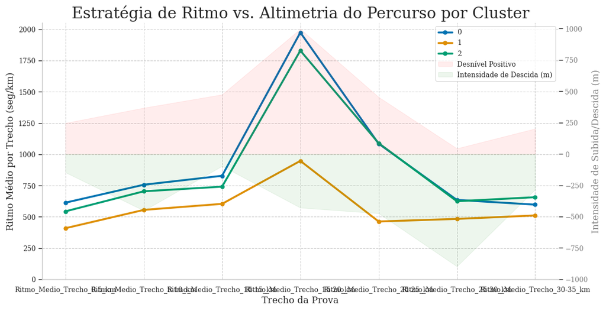

```python
# Crie a figura e o primeiro eixo (para o ritmo)
fig, ax1 = plt.subplots(figsize=(12, 6))

# Pegando apenas as colunas de ritmo por trecho da sua tabela de perfis
colunas_ritmo_trechos = [
    "Ritmo_Medio_Trecho_0-5_km",
    "Ritmo_Medio_Trecho_5-10_km",
    "Ritmo_Medio_Trecho_10-15_km",
    "Ritmo_Medio_Trecho_15-20_km",
    "Ritmo_Medio_Trecho_20-25_km",
    "Ritmo_Medio_Trecho_25-30_km",
    "Ritmo_Medio_Trecho_30-35_km",
]
perfis_ritmo = perfis_clusters2[
    colunas_ritmo_trechos
].T  # .T para transpor (facilita o plot)


# Plote o gráfico de linhas do ritmo no primeiro eixo (ax1)
perfis_ritmo.plot(
    ax=ax1, marker="o", linewidth=2.5, zorder=10
)  # zorder alto para ficar na frente

# Estética do eixo 1 (Ritmo)
ax1.set_title("Estratégia de Ritmo vs. Altimetria do Percurso por Cluster", fontsize=20)
ax1.set_xlabel("Trecho da Prova", fontsize=12)
ax1.set_ylabel("Ritmo Médio por Trecho (seg/km)", fontsize=12)
ax1.grid(True, linestyle="--", which="both")
ax1.legend(title="Cluster")
ax1.set_ylim(bottom=0)  # Garante que o eixo Y do ritmo comece no zero

# Crie o segundo eixo (para o desnível)
ax2 = ax1.twinx()

# Plote o GRÁFICO DE ÁREA do desnível no segundo eixo (ax2)
ax2.fill_between(
    df_desnivel.index,
    df_desnivel["desnivel_positivo"],
    y2=0,  # Linha base do preenchimento
    color="red",
    alpha=0.07,
    label="Desnível Positivo",
    zorder=0,  # zorder baixo para ficar no fundo
)

# Estética do eixo 2 (Desnível)
ax2.set_ylabel("Desnível Positivo Acumulado (m)", color="gray", fontsize=12)
ax2.tick_params(axis="y", labelcolor="gray")
ax2.grid(False)
ax2.set_ylim(bottom=-100)  # Garante que o eixo Y do desnível comece no zero

# Plotando a ÁREA para DESNÍVEL NEGATIVO (Descidas)
ax2.fill_between(
    df_desnivel.index,
    df_desnivel["desnivel_negativo"],
    y2=0,
    color="green",  # Cor diferente para as descidas
    alpha=0.07,
    label="Intensidade de Descida (m)",
    zorder=0,
)

ax2.set_ylabel("Intensidade de Subida/Descida (m)", color="gray", fontsize=12)
ax2.tick_params(axis="y", labelcolor="gray")
ax2.grid(False)
ax2.set_ylim(bottom=-1000)

# Unificar as legendas
lines, labels = ax1.get_legend_handles_labels()
areas, area_labels = ax2.get_legend_handles_labels()
ax1.legend(lines + areas, labels + area_labels, loc="upper right")

plt.show()
```

```python
df_with_clusters.columns
```

```
Index(['Unnamed: 0', 'sexo', 'faixa_etaria', 'peso', 'Tempo_Final_seg', 'Ritmo_Medio_seg', 'Variabilidade_Ritmo_std', 'Variabilidade_Ritmo_min_std', 'Ritmo_Medio_Primeira_Metade', 'Ritmo_Medio_Segunda_Metade', 'Tempo_Total_Primeira_Metade', 'Tempo_Total_Segunda_Metade', 'Diferenca_Media_Seg_Menos_Pr…
       'Tempo_Total_PLANO', 'Tempo_Total_SUBIDA', 'indice_subida', 'indice_descida_vs_subida', 'indice_descida', 'indice_especializacao', 'indice_capacidade_geral', 'cluster'],
      dtype='object')
```

```python
colunas_ritmo_trechos = [
    "indice_subida",
    "indice_descida",
    "Ritmo_Medio_Trecho_10-15_km",
    "Ritmo_Medio_Trecho_15-20_km",
    "Ritmo_Medio_Trecho_20-25_km",
    "Ritmo_Medio_Trecho_25-30_km",
    "Ritmo_Medio_Trecho_30-35_km",
    "cluster",
]
perfis_clusters2 = (
    df_with_clusters[colunas_ritmo_trechos].groupby("cluster").median().round(2)
)
perfis_clusters2.head()
```

| cluster | indice_subida | indice_descida | Ritmo_Medio_Trecho_10-15_km | Ritmo_Medio_Trecho_15-20_km | Ritmo_Medio_Trecho_20-25_km | Ritmo_Medio_Trecho_25-30_km | Ritmo_Medio_Trecho_30-35_km |
| --- | --- | --- | --- | --- | --- | --- | --- |
| 0 | 0.24 | -0.21 | 828.2 | 1974.4 | 1085.2 | 635.0 | 597.4 |
| 1 | 0.19 | -0.14 | 603.6 | 947.4 | 462.6 | 483.2 | 510.6 |
| 2 | 0.27 | -0.19 | 741.2 | 1829.6 | 1089.4 | 624.4 | 656.8 |

```python
colunas_ritmo_trechos = [
    "sexo",
    "cluster",
]
perfis_clusters2 = (
    df_with_clusters[colunas_ritmo_trechos].groupby("cluster").value_counts().round(2)
)
perfis_clusters2.head()
```

```
cluster  sexo
0        Mulheres    11
         Homens       8
1        Homens      49
         Mulheres    14
2        Homens      21
Name: count, dtype: int64
```

```python
perfis_clusters2 = (
    df_with_clusters[["Ritmo_Medio_DESCIDA", "Ritmo_Medio_SUBIDA", "cluster", "sexo"]]
    .groupby(["cluster", "sexo"])
    .median()
    .round(2)
)
perfis_clusters2.head()
```

| cluster | sexo | Ritmo_Medio_DESCIDA | Ritmo_Medio_SUBIDA |
| --- | --- | --- | --- |
| 0 | Homens | 754.07 | 1159.85 |
|  | Mulheres | 725.73 | 1128.24 |
| 1 | Homens | 480.47 | 674.59 |
|  | Mulheres | 498.97 | 718.06 |
| 2 | Homens | 658.00 | 1094.24 |

## Regressão

### Preparação das Variáveis (Feature Engineering)

```python
import pandas as pd
import numpy as np

# Supondo que 'df_with_clusters' já está carregado e contém seus dados

# --- 1. Codificar a variável 'sexo' em uma variável binária (0=Mulher, 1=Homem) ---
# Usamos o método .map() para uma substituição direta.
df_with_clusters["sexo_masculino"] = df_with_clusters["sexo"].map(
    {"Homens": 1, "Mulheres": 0}
)


# --- 2. Codificar a 'faixa_etaria' em uma variável ordinal numérica (1 a 5) ---
# Primeiro, definimos a ordem correta das categorias
faixa_etaria_niveis = ["20 a 24", "25 a 34", "35 a 44", "45 a 54", "55 a 64"]

# Criamos uma coluna do tipo Categoria Ordenada no pandas
df_with_clusters["faixa_etaria_ord"] = pd.Categorical(
    df_with_clusters["faixa_etaria"], categories=faixa_etaria_niveis, ordered=True
)

# Extraímos os códigos numéricos (que começam em 0) e somamos 1 para ficarem de 1 a 5
df_with_clusters["faixa_etaria_num"] = (
    df_with_clusters["faixa_etaria_ord"].cat.codes + 1
)


# --- 3. Codificar a variável 'peso' para o ponto médio da faixa em kg ---
# Criamos um dicionário para mapear as faixas para os valores numéricos
mapeamento_peso = {
    "54 kg e abaixo": 54.0,
    "55 a 64 kg": 59.5,
    "65 a 74 kg": 69.5,
    "75 a 84 kg": 79.5,
    "85 a 94 kg": 89.5,
    "95 kg a 104 kg": 99.5,
    "Não informado": np.nan,  # np.nan é o equivalente a NA do R
}

df_with_clusters["peso_kg"] = df_with_clusters["peso"].map(mapeamento_peso)


# --- (Opcional) Criar a variável logarítmica do tempo para os modelos M_log ---
df_with_clusters["log_Tempo_Final_seg"] = np.log(df_with_clusters["Tempo_Final_seg"])


# Visualizar as novas colunas criadas para garantir que tudo está correto
print("Visualização das novas colunas:")
print(
    df_with_clusters[
        [
            "sexo",
            "sexo_masculino",
            "faixa_etaria",
            "faixa_etaria_num",
            "peso",
            "peso_kg",
            "log_Tempo_Final_seg",
        ]
    ].head()
)
```

```
Visualização das novas colunas:
                          sexo  sexo_masculino faixa_etaria  faixa_etaria_num        peso  peso_kg  log_Tempo_Final_seg
Nome Atleta
ALFREDO GUIMARAES       Homens               1      45 a 54                 4  75 a 84 kg     79.5             9.988472
Albert Melo             Homens               1      25 a 34                 2  75 a 84 kg     79.5            10.373054
Alessandro Sousa(allê)  Homens               1      45 a 54                 4  65 a 74 kg     69.5            10.428985
Alex Junior Aj          Homens               1      20 a 24                 1  65 a 74 kg     69.5             9.825310
Alexandre Santiago      Homens               1      35 a 44                 3  55 a 64 kg     59.5             9.590556
```

### Definição dos Modelos de Regressão

**O Propósito de Cada Modelo**

- **M1 (Modelo Demográfico)**: Testa o poder preditivo apenas das características básicas do corredor (sexo, idade, peso).
- **M2 (Modelo de Clusters)**: Adiciona os perfis de cluster para ver se eles explicam a performance além da demografia.
- **M3 (Modelo Técnico)**: Ignora os clusters e usa apenas as métricas de performance contínuas que criamos. Testa se essas métricas sozinhas são boas preditoras.
- **M4 (Modelo Completo Aditivo)**: Junta tudo (demografia, clusters e métricas) para ver se os clusters ainda têm um efeito independente quando tudo mais é controlado.
- **M5 (Modelo de Interação)**: O mais complexo. Testa se o efeito de uma métrica técnica (ex: variabilidade) é diferente para cada cluster. Por exemplo, será que ser inconsistente (alta variabilidade) penaliza mais o tempo de um "Elite" do que o de um "Amador"?
- **M_log (Modelos com Log)**: Testa se a relação entre as variáveis e o tempo fica mais linear (e os erros do modelo mais bem comportados) quando usamos o logaritmo do tempo. É uma transformação comum para "puxar" valores extremos para perto da média.

```python
import statsmodels.formula.api as smf

# Nota: O código abaixo apenas DEFINE as fórmulas dos modelos.
# Ele não os 'treina' ou mostra os resultados ainda. Faremos isso na próxima etapa.

print("\n--- Definição dos Modelos de Regressão ---")

# Modelo M1: Apenas variáveis demográficas
formula_m1 = "Tempo_Final_seg ~ sexo_masculino + faixa_etaria_num + peso_kg"
m1 = smf.ols(formula=formula_m1, data=df_with_clusters)
print("Modelo M1 definido.")

# Modelo M2: Demografia + Clusters
# C(cluster) diz ao statsmodels para tratar 'cluster' como uma variável categórica (criando dummies)
formula_m2 = (
    "Tempo_Final_seg ~ sexo_masculino + faixa_etaria_num + peso_kg + C(cluster)"
)
m2 = smf.ols(formula=formula_m2, data=df_with_clusters)
print("Modelo M2 definido.")

# Modelo M3: Demografia + Métricas Técnicas
formula_m3 = (
    "Tempo_Final_seg ~ sexo_masculino + faixa_etaria_num + peso_kg + "
    "Variabilidade_Ritmo_std + indice_capacidade_geral + "
    "indice_especializacao + diff_relativa_segunda_primeira_parte"
)
m3 = smf.ols(formula=formula_m3, data=df_with_clusters)
print("Modelo M3 definido.")

# Modelo M4: Demografia + Clusters + Métricas Técnicas (sem interação)
# Modelo M3: Demografia + Métricas Técnicas
formula_m4 = (
    "Tempo_Final_seg ~ sexo_masculino + faixa_etaria_num + peso_kg + "
    "Variabilidade_Ritmo_std + indice_capacidade_geral + "
    "indice_especializacao + diff_relativa_segunda_primeira_parte + C(cluster)"
)
m4 = smf.ols(formula=formula_m4, data=df_with_clusters)
print("Modelo M4 definido.")

# Modelo M5: Demografia + Métricas Técnicas COM INTERAÇÃO com os Clusters
# O '*' na fórmula cria os efeitos principais e o termo de interação
formula_m5 = (
    "Tempo_Final_seg ~ sexo_masculino + faixa_etaria_num + peso_kg + "
    "Variabilidade_Ritmo_std * C(cluster) + "
    "indice_capacidade_geral * C(cluster) + "
    "indice_especializacao * C(cluster) + "
    "diff_relativa_segunda_primeira_parte * C(cluster)"
)
m5 = smf.ols(formula=formula_m5, data=df_with_clusters)
print("Modelo M5 (com interação) definido.")

# Modelo M_simples: Apenas Variabilidade com Interação
formula_m_simples = "Tempo_Final_seg ~ Variabilidade_Ritmo_std * C(cluster)"
m_simples = smf.ols(formula=formula_m_simples, data=df_with_clusters)
print("Modelo M_simples definido.")

# Modelo M_log: Versão logarítmica do M_simples
formula_m_log = "log_Tempo_Final_seg ~ Variabilidade_Ritmo_std * C(cluster)"
m_log = smf.ols(formula=formula_m_log, data=df_with_clusters)
print("Modelo M_log definido.")

# Modelo M_log1: Modelo completo na escala logarítmica
formula_m_log1 = (
    "log_Tempo_Final_seg ~ Variabilidade_Ritmo_std * C(cluster) + "
    "sexo_masculino + faixa_etaria_num + peso_kg + indice_capacidade_geral + "
    "indice_especializacao + diff_relativa_segunda_primeira_parte"
)
m_log1 = smf.ols(formula=formula_m_log1, data=df_with_clusters)
print("Modelo M_log1 definido.")

# Modelo M_linear: Modelo completo na escala original (linear)
# Este é o modelo mais completo com interação apenas na variável principal
formula_m_linear = (
    "Tempo_Final_seg ~ Variabilidade_Ritmo_std * C(cluster) + "
    "sexo_masculino + faixa_etaria_num + peso_kg + "
    "indice_capacidade_geral + indice_especializacao + "
    "diff_relativa_segunda_primeira_parte"
)
m_linear = smf.ols(formula=formula_m_linear, data=df_with_clusters)
print("Modelo M_linear definido.")
```

```
--- Definição dos Modelos de Regressão ---
Modelo M1 definido.
Modelo M2 definido.
Modelo M3 definido.
Modelo M4 definido.
Modelo M5 (com interação) definido.
Modelo M_simples definido.
Modelo M_log definido.
Modelo M_log1 definido.
Modelo M_linear definido.
```

```python
# Supondo que 'df_with_clusters' e todas as fórmulas (formula_m1, etc.) já existem.

# Lista dos modelos e seus nomes para comparação
modelos_para_comparar = {
    "M1 (Demográfico)": m1,
    "M2 (Demog + Cluster)": m2,
    "M3 (Demog + Técnicas)": m3,
    "M4 (Demog + Técnicas + clsuter)": m4,
    "M5 (Demog + Interação)": m5,
    "M_simples (Var*Cluster)": m_simples,
    "M_linear (Completo)": m_linear,
    "M_log (Var*Cluster)": m_log,
    "M_log1 (Completo)": m_log1,
}

# Dicionário para armazenar os resultados
resultados_comparacao = {}

print("--- Ajustando modelos e extraindo métricas... ---")

for nome, modelo in modelos_para_comparar.items():
    # Ajusta (treina) o modelo, removendo linhas com dados faltantes
    resultado = modelo.fit()

    # Armazena as métricas de interesse
    resultados_comparacao[nome] = {
        "R² Ajustado": round(resultado.rsquared_adj, 4),
        "AIC": round(resultado.aic, 2),
        "BIC": round(resultado.bic, 2),
    }

# Cria um DataFrame do pandas com os resultados para fácil visualização
tabela_comparativa = pd.DataFrame.from_dict(resultados_comparacao, orient="index")

# Ordena a tabela pelo AIC (menor é melhor) para ver o ranking
tabela_comparativa_ordenada = tabela_comparativa.sort_values(by="AIC")

print("\n--- Tabela Comparativa de Modelos (Ordenada por AIC) ---")
print(tabela_comparativa_ordenada)
```

```
--- Ajustando modelos e extraindo métricas... ---

--- Tabela Comparativa de Modelos (Ordenada por AIC) ---
                                 R² Ajustado      AIC      BIC
M_log1 (Completo)                     0.9281  -219.46  -188.08
M_log (Var*Cluster)                   0.8923  -201.60  -185.45
M4 (Demog + Técnicas + clsuter)       0.9342  1823.43  1849.59
M5 (Demog + Interação)                0.9384  1823.51  1870.59
M3 (Demog + Técnicas)                 0.9330  1823.52  1844.45
M_linear (Completo)                   0.9344  1824.90  1856.28
M2 (Demog + Cluster)                  0.6931  1975.32  1991.02
M_simples (Var*Cluster)               0.9111  1992.96  2009.10
M1 (Demográfico)                      0.2306  2066.26  2076.72
```

```python
# --- Para analisar o melhor modelo em mais detalhe ---
print("\n--- Resumo do Melhor Modelo (com base no menor AIC) ---")

# Ajusta novamente o melhor modelo para mostrar seu resumo completo
melhor_modelo = m_log1.fit()
print(melhor_modelo.summary())
```

```
--- Resumo do Melhor Modelo (com base no menor AIC) ---
                             OLS Regression Results
===============================================================================
Dep. Variable:     log_Tempo_Final_seg   R-squared:                       0.936
Model:                             OLS   Adj. R-squared:                  0.928
Method:                  Least Squares   F-statistic:                     118.3
Date:                 Thu, 09 Oct 2025   Prob (F-statistic):           3.68e-48
Time:                         18:20:28   Log-Likelihood:                 121.73
No. Observations:                  101   AIC:                            -219.5
Df Residuals:                       89   BIC:                            -188.1
Df Model:                           11
Covariance Type:             nonrobust
===========================================================================================================
                                              coef    std err          t      P>|t|      [0.025      0.975]
-----------------------------------------------------------------------------------------------------------
Intercept                                   9.6664      0.102     94.505      0.000       9.463       9.870
C(cluster)[T.1]                            -0.3986      0.101     -3.961      0.000      -0.599      -0.199
C(cluster)[T.2]                            -0.2592      0.101     -2.556      0.012      -0.461      -0.058
Variabilidade_Ritmo_std                     0.0010      0.000      8.370      0.000       0.001       0.001
Variabilidade_Ritmo_std:C(cluster)[T.1]     0.0010      0.000      4.589      0.000       0.001       0.001
Variabilidade_Ritmo_std:C(cluster)[T.2]     0.0003      0.000      2.010      0.047    3.72e-06       0.001
sexo_masculino                             -0.1228      0.025     -4.971      0.000      -0.172      -0.074
faixa_etaria_num                            0.0097      0.010      1.000      0.320      -0.010       0.029
peso_kg                                     0.0036      0.001      3.685      0.000       0.002       0.005
indice_capacidade_geral                     1.0647      0.651      1.634      0.106      -0.230       2.359
indice_especializacao                       0.1595      0.184      0.869      0.387      -0.205       0.524
diff_relativa_segunda_primeira_parte        0.4062      0.121      3.350      0.001       0.165       0.647
==============================================================================
Omnibus:                        0.031   Durbin-Watson:                   1.954
Prob(Omnibus):                  0.985   Jarque-Bera (JB):                0.173
Skew:                           0.014   Prob(JB):                        0.917
Kurtosis:                       2.799   Cond. No.                     4.43e+04
==============================================================================

Notes:
[1] Standard Errors assume that the covariance matrix of the errors is correctly specified.
[2] The condition number is large, 4.43e+04. This might indicate that there are
strong multicollinearity or other numerical problems.
```

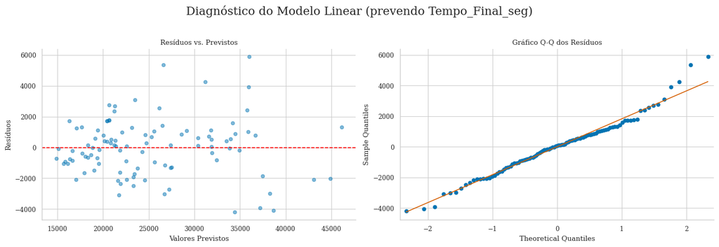

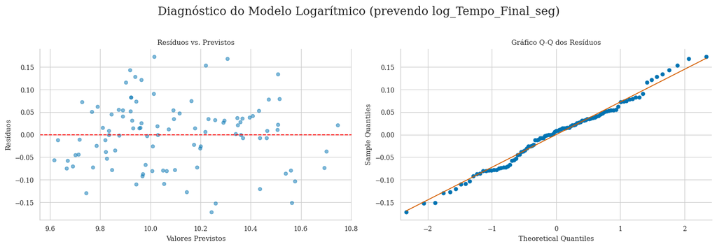

```python
import matplotlib.pyplot as plt
import statsmodels.api as sm
import numpy as np

# Supondo que 'm_linear' e 'm_log1' são seus melhores modelos de cada tipo.
# Primeiro, precisamos ajustar (treinar) os modelos.
resultados_linear = m4.fit()
resultados_log = m_log1.fit()


def plotar_diagnostico_residuos(resultados, titulo):
    """
    Função para gerar gráficos de diagnóstico de resíduos para um modelo ajustado.
    """
    fig, axs = plt.subplots(1, 2, figsize=(14, 5))
    fig.suptitle(titulo, fontsize=16)

    # 1. Gráfico de Resíduos vs. Valores Previstos (para checar Homocedasticidade)
    previsoes = resultados.predict()
    residuos = resultados.resid
    axs[0].scatter(previsoes, residuos, alpha=0.5)
    axs[0].axhline(0, color="red", linestyle="--")
    axs[0].set_xlabel("Valores Previstos")
    axs[0].set_ylabel("Resíduos")
    axs[0].set_title("Resíduos vs. Previstos")

    # 2. Gráfico Q-Q dos Resíduos (para checar Normalidade)
    sm.qqplot(residuos, line="s", ax=axs[1])
    axs[1].set_title("Gráfico Q-Q dos Resíduos")

    plt.tight_layout(rect=[0, 0.03, 1, 0.95])
    plt.show()


# Gerar os gráficos para o melhor modelo LINEAR
plotar_diagnostico_residuos(
    resultados_linear, "Diagnóstico do Modelo Linear (prevendo Tempo_Final_seg)"
)

# Gerar os gráficos para o melhor modelo LOG
plotar_diagnostico_residuos(
    resultados_log, "Diagnóstico do Modelo Logarítmico (prevendo log_Tempo_Final_seg)"
)
```

```python
from sklearn.metrics import mean_squared_error
import numpy as np

# Supondo que 'resultados_linear' e 'resultados_log' já foram ajustados.

# --- Para o Modelo Linear ---
# Os valores reais (endog) e as previsões (fittedvalues) já estão na escala original
# e perfeitamente alinhados pelo statsmodels.
tempo_real_linear = resultados_linear.model.endog
previsoes_linear = resultados_linear.fittedvalues

# --- Para o Modelo Logarítmico ---
# Os valores reais (endog) e as previsões (fittedvalues) estão na escala LOG.
# Precisamos transformá-los de volta para a escala original (segundos) usando np.exp().
tempo_real_log_original = np.exp(resultados_log.model.endog)
previsoes_log_original = np.exp(resultados_log.fittedvalues)

# --- Calcular o RMSE para ambos os modelos na escala original (segundos) ---
rmse_linear = np.sqrt(mean_squared_error(tempo_real_linear, previsoes_linear))
rmse_log = np.sqrt(mean_squared_error(tempo_real_log_original, previsoes_log_original))

print("--- Comparação da Precisão Preditiva (RMSE) na Escala Original ---")
print(f"RMSE do Modelo Linear: {rmse_linear:.2f} segundos")
print(f"RMSE do Modelo Logarítmico: {rmse_log:.2f} segundos")

print("\nLembrete: O modelo com MENOR RMSE tem melhor precisão preditiva.")

# Determinar e imprimir qual modelo é melhor
if rmse_linear < rmse_log:
    print("Conclusão: O Modelo Linear é preditivamente mais preciso.")
else:
    print("Conclusão: O Modelo Logarítmico é preditivamente mais preciso.")
```

```
--- Comparação da Precisão Preditiva (RMSE) na Escala Original ---
RMSE do Modelo Linear: 1824.30 segundos
RMSE do Modelo Logarítmico: 1942.64 segundos

Lembrete: O modelo com MENOR RMSE tem melhor precisão preditiva.
Conclusão: O Modelo Linear é preditivamente mais preciso.
```

### Diagnostico do Modelo

```python
modelos_para_comparar = {
    "M1 (Demográfico)": m1,
    "M2 (Demog + Cluster)": m2,
    "M3 (Demog + Técnicas)": m3,
    "M4 (Demog + Técnicas + cluster)": m4,
    "M5 (Demog + Interação)": m5,
    "M_simples (Var*Cluster)": m_simples,
    "M_linear (Completo)": m_linear,
    "M_log (Var*Cluster)": m_log,
    "M_log1 (Completo)": m_log1,
}

print("--- Ajustando modelos e testando normalidade... ---")

for nome, modelo in modelos_para_comparar.items():
    # Ajusta (treina) o modelo, removendo linhas com dados faltantes
    resultado = modelo.fit()
    residuos = resultado.resid

    # --- Teste de Shapiro-Wilk ---
    # H₀: Os resíduos são normalmente distribuídos. Se p < 0.05, rejeitamos H₀.
    shapiro_test = stats.shapiro(residuos)
    print(f"--- Teste de Normalidade (Shapiro-Wilk) - MODELO: {nome} ---")
    print(f"Estatística do teste: {shapiro_test.statistic:.4f}")
    print(f"P-valor: {shapiro_test.pvalue:.4f}")
    if shapiro_test.pvalue < 0.05:
        print("Conclusão: Os resíduos NÃO são normalmente distribuídos.\n")
    else:
        print(
            "Conclusão: Não há evidências para rejeitar a normalidade dos resíduos.\n"
        )
```

[output not shown]

```
--- Teste de Normalidade (Shapiro-Wilk) ---
Estatística do teste: 0.9880
P-valor: 0.5024
Conclusão: Não há evidências para rejeitar a normalidade dos resíduos.
```

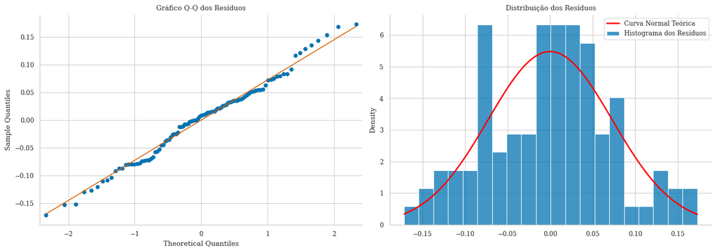

```python
resultados_m_log1 = m_log1.fit()
residuos = resultados_m_log1.resid

# --- Teste de Shapiro-Wilk ---
# H₀: Os resíduos são normalmente distribuídos. Se p < 0.05, rejeitamos H₀.
shapiro_test = stats.shapiro(residuos)
print(f"--- Teste de Normalidade (Shapiro-Wilk) ---")
print(f"Estatística do teste: {shapiro_test.statistic:.4f}")
print(f"P-valor: {shapiro_test.pvalue:.4f}")
if shapiro_test.pvalue < 0.05:
    print("Conclusão: Os resíduos NÃO são normalmente distribuídos.\n")
else:
    print("Conclusão: Não há evidências para rejeitar a normalidade dos resíduos.\n")

# --- Gráficos de Diagnóstico de Normalidade ---
fig, axs = plt.subplots(1, 2, figsize=(14, 5))

# Gráfico Q-Q (Quantil-Quantil)
sm.qqplot(residuos, line="s", ax=axs[0])
axs[0].set_title("Gráfico Q-Q dos Resíduos")

# Histograma com curva de densidade normal
sns.histplot(
    residuos,
    kde=False,
    stat="density",
    bins=20,
    ax=axs[1],
    label="Histograma dos Resíduos",
)
# Adiciona a curva normal teórica para comparação
x_range = np.linspace(residuos.min(), residuos.max(), 100)
mean, std = residuos.mean(), residuos.std()
axs[1].plot(
    x_range,
    stats.norm.pdf(x_range, mean, std),
    color="red",
    lw=2,
    label="Curva Normal Teórica",
)
axs[1].set_title("Distribuição dos Resíduos")
axs[1].legend()

plt.tight_layout()
plt.show()

# --- (Opcional) Gráficos de diagnóstico padrão do statsmodels (similar ao plot(modelo) do R) ---
# fig = plt.figure(figsize=(12, 8))
# sm.graphics.plot_regress_exog(resultados_m_log1, 'Variabilidade_Ritmo_std', fig=fig)
# plt.show()
```

[output not shown]

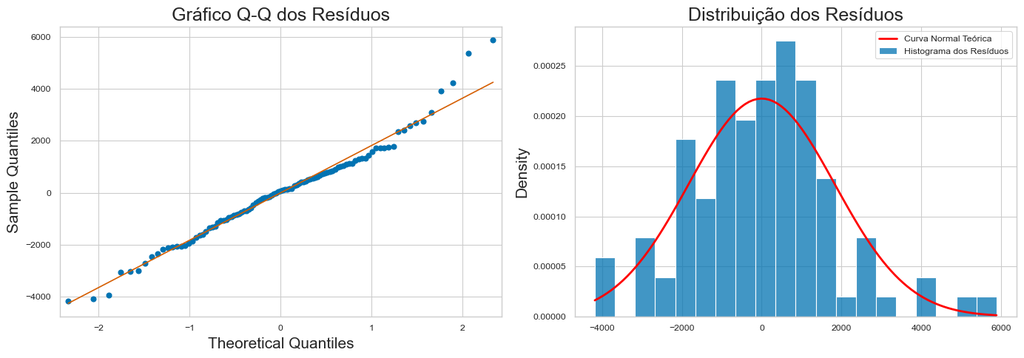

```python
resultados_m4 = m4.fit()
residuos = resultados_m4.resid

# --- Teste de Shapiro-Wilk ---
# H₀: Os resíduos são normalmente distribuídos. Se p < 0.05, rejeitamos H₀.
shapiro_test = stats.shapiro(residuos)
print(f"--- Teste de Normalidade (Shapiro-Wilk) ---")
print(f"Estatística do teste: {shapiro_test.statistic:.4f}")
print(f"P-valor: {shapiro_test.pvalue:.4f}")
if shapiro_test.pvalue < 0.05:
    print("Conclusão: Os resíduos NÃO são normalmente distribuídos.\n")
else:
    print("Conclusão: Não há evidências para rejeitar a normalidade dos resíduos.\n")

# --- Gráficos de Diagnóstico de Normalidade ---
fig, axs = plt.subplots(1, 2, figsize=(14, 5))

# Gráfico Q-Q (Quantil-Quantil)
sm.qqplot(residuos, line="s", ax=axs[0])
axs[0].set_title("Gráfico Q-Q dos Resíduos")

# Histograma com curva de densidade normal
sns.histplot(
    residuos,
    kde=False,
    stat="density",
    bins=20,
    ax=axs[1],
    label="Histograma dos Resíduos",
)
# Adiciona a curva normal teórica para comparação
x_range = np.linspace(residuos.min(), residuos.max(), 100)
mean, std = residuos.mean(), residuos.std()
axs[1].plot(
    x_range,
    stats.norm.pdf(x_range, mean, std),
    color="red",
    lw=2,
    label="Curva Normal Teórica",
)
axs[1].set_title("Distribuição dos Resíduos")
axs[1].legend()

plt.tight_layout()
plt.show()

# --- (Opcional) Gráficos de diagnóstico padrão do statsmodels (similar ao plot(modelo) do R) ---
# fig = plt.figure(figsize=(12, 8))
# sm.graphics.plot_regress_exog(resultados_m_log1, 'Variabilidade_Ritmo_std', fig=fig)
# plt.show()
```

```
--- Análise Gráfica ---
```

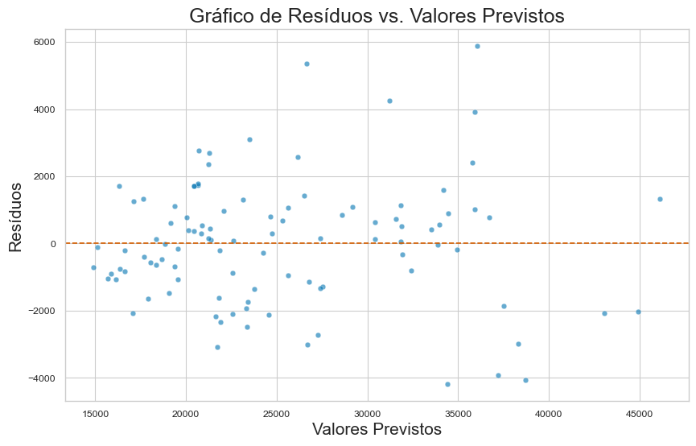

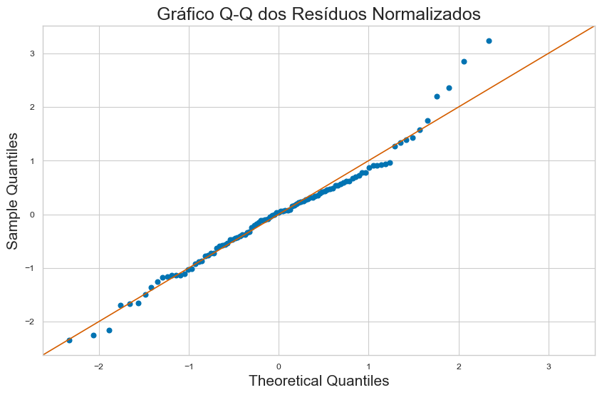

```
--- Testes Estatísticos ---
Teste de Shapiro-Wilk para Normalidade dos Resíduos:
  - Estatística do teste: 0.9797
  - p-valor: 0.1214
  - Conclusão: p-valor > 0.05. Não há evidências para rejeitar a hipótese de normalidade dos resíduos.

Teste de Breusch-Pagan para Homocedasticidade:
  - Estatística do teste (LM): 20.3923
  - p-valor: 0.0156
  - Conclusão: p-valor < 0.05. A hipótese de homocedasticidade é rejeitada (temos heterocedasticidade).
```

```python
from statsmodels.stats.diagnostic import het_breuschpagan


model = m4.fit()
valores_previstos = model.fittedvalues
# Resíduos (diferença entre o valor real e o previsto)
residuos = model.resid
# Resíduos normalizados
residuos_normalizados = model.get_influence().resid_studentized_internal

# Configurando o estilo dos gráficos
sns.set_style("whitegrid")
plt.rc("font", size=12)
plt.rc("axes", titlesize=18)
plt.rc("axes", labelsize=15)

# --- 1. GRÁFICO PARA LINEARIDADE E HOMOCEDASTICIDADE ---
# (Resíduos vs. Valores Previstos)
print("--- Análise Gráfica ---")
plt.figure(figsize=(10, 6))
sns.scatterplot(x=valores_previstos, y=residuos, alpha=0.6)
plt.axhline(y=0, color="r", linestyle="--")
plt.xlabel("Valores Previstos")
plt.ylabel("Resíduos")
plt.title("Gráfico de Resíduos vs. Valores Previstos")
plt.show()

# --- 2. GRÁFICO PARA NORMALIDADE DOS RESÍDUOS ---
# (Gráfico Q-Q)
plt.figure(figsize=(10, 6))
sm.qqplot(residuos_normalizados, line="45", fit=True, ax=plt.gca())
plt.title("Gráfico Q-Q dos Resíduos Normalizados")
plt.show()

# --- 3. TESTES ESTATÍSTICOS ---
print("\n--- Testes Estatísticos ---")
# Teste de Shapiro-Wilk para Normalidade
shapiro_test = stats.shapiro(residuos)
print(f"Teste de Shapiro-Wilk para Normalidade dos Resíduos:")
print(f"  - Estatística do teste: {shapiro_test.statistic:.4f}")
print(f"  - p-valor: {shapiro_test.pvalue:.4f}")
if shapiro_test.pvalue > 0.05:
    print(
        "  - Conclusão: p-valor > 0.05. Não há evidências para rejeitar a hipótese de normalidade dos resíduos.\n"
    )
else:
    print(
        "  - Conclusão: p-valor < 0.05. A hipótese de normalidade dos resíduos é rejeitada.\n"
    )

# Teste de Breusch-Pagan para Homocedasticidade
# model.model.exog são as variáveis preditoras que o statsmodels usou
breusch_pagan_test = het_breuschpagan(residuos, model.model.exog)
labels = ["Estatística LM", "p-valor do LM", "Estatística F", "p-valor do F"]
print(f"Teste de Breusch-Pagan para Homocedasticidade:")
print(f"  - Estatística do teste (LM): {breusch_pagan_test[0]:.4f}")
print(f"  - p-valor: {breusch_pagan_test[1]:.4f}")
if breusch_pagan_test[1] > 0.05:
    print(
        "  - Conclusão: p-valor > 0.05. Não há evidências para rejeitar a hipótese de homocedasticidade (variância constante).\n"
    )
else:
    print(
        "  - Conclusão: p-valor < 0.05. A hipótese de homocedasticidade é rejeitada (temos heterocedasticidade).\n"
    )
```

#### # --- Teste de Breusch-Pagan ---

> H₀: A variância é constante (homocedasticidade). Se p < 0.05, rejeitamos H₀.
- O teste requer os resíduos e a matriz de variáveis preditoras (exog).

```python
import statsmodels.stats.api as sms

resultados_m_log1 = m_log1.fit()
residuos = resultados_m_log1.resid

bp_test = sms.het_breuschpagan(resultados_m_log1.resid, resultados_m_log1.model.exog)
labels = ["Estatística LM", "p-valor LM", "Estatística F", "p-valor F"]
bp_resultado = dict(zip(labels, bp_test))

print(f"--- Teste de Homogeneidade de Variância (Breusch-Pagan) ---")
print(f"P-valor (baseado em F): {bp_resultado['p-valor F']:.4f}")

if bp_resultado["p-valor F"] < 0.05:
    print("Conclusão: H₀ rejeitada. Há evidência de HETEROCEDASTICIDADE (problema).\n")
else:
    print("Conclusão: H₀ não rejeitada. Não há evidência de heterocedasticidade.\n")
```

```
--- Teste de Homogeneidade de Variância (Breusch-Pagan) ---
P-valor (baseado em F): 0.0081
Conclusão: H₀ rejeitada. Há evidência de HETEROCEDASTICIDADE (problema).
```

```python
import statsmodels.stats.api as sms

resultados_m4 = m4.fit()
residuos = resultados_m4.resid

bp_test = sms.het_breuschpagan(resultados_m4.resid, resultados_m4.model.exog)
labels = ["Estatística LM", "p-valor LM", "Estatística F", "p-valor F"]
bp_resultado = dict(zip(labels, bp_test))

print(f"--- Teste de Homogeneidade de Variância (Breusch-Pagan) ---")
print(f"P-valor (baseado em F): {bp_resultado['p-valor F']:.4f}")

if bp_resultado["p-valor F"] < 0.05:
    print("Conclusão: H₀ rejeitada. Há evidência de HETEROCEDASTICIDADE (problema).\n")
else:
    print("Conclusão: H₀ não rejeitada. Não há evidência de heterocedasticidade.\n")
```

```
--- Teste de Homogeneidade de Variância (Breusch-Pagan) ---
P-valor (baseado em F): 0.0114
Conclusão: H₀ rejeitada. Há evidência de HETEROCEDASTICIDADE (problema).
```

#### --- Teste de Durbin-Watson --

```python
from statsmodels.stats.stattools import durbin_watson

# Supondo que 'resultados_m_log1' já foi ajustado

# --- Teste de Durbin-Watson ---
# A estatística varia de 0 a 4. Valores próximos de 2 indicam ausência de autocorrelação.
dw_statistic = durbin_watson(resultados_m_log1.resid)

print(f"--- Teste de Independência dos Resíduos (Durbin-Watson) ---")
print(f"Estatística Durbin-Watson: {dw_statistic:.4f}")
print(
    "Conclusão: O valor está próximo de 2, indicando que o pressuposto de independência dos resíduos foi atendido.\n"
)
```

```
--- Teste de Independência dos Resíduos (Durbin-Watson) ---
Estatística Durbin-Watson: 1.9540
Conclusão: O valor está próximo de 2, indicando que o pressuposto de independência dos resíduos foi atendido.
```

```python
# --- Reajustando o modelo com erros padrão robustos (HC3) ---
# A única mudança é adicionar o argumento cov_type='HC3' ao método .fit()
resultados_robustos_m_log1 = m_log1.fit(cov_type="HC3")

print("=" * 70)
print("     RESULTADO FINAL DO MODELO COM ERROS PADRÃO ROBUSTOS (HC3)")
print("=" * 70)
print(resultados_robustos_m_log1.summary())
```

```
======================================================================
     RESULTADO FINAL DO MODELO COM ERROS PADRÃO ROBUSTOS (HC3)
======================================================================
                             OLS Regression Results
===============================================================================
Dep. Variable:     log_Tempo_Final_seg   R-squared:                       0.936
Model:                             OLS   Adj. R-squared:                  0.928
Method:                  Least Squares   F-statistic:                     124.0
Date:                 Thu, 09 Oct 2025   Prob (F-statistic):           5.25e-49
Time:                         19:20:23   Log-Likelihood:                 121.73
No. Observations:                  101   AIC:                            -219.5
Df Residuals:                       89   BIC:                            -188.1
Df Model:                           11
Covariance Type:                   HC3
===========================================================================================================
                                              coef    std err          z      P>|z|      [0.025      0.975]
-----------------------------------------------------------------------------------------------------------
Intercept                                   9.6664      0.139     69.715      0.000       9.395       9.938
C(cluster)[T.1]                            -0.3986      0.147     -2.717      0.007      -0.686      -0.111
C(cluster)[T.2]                            -0.2592      0.115     -2.248      0.025      -0.485      -0.033
Variabilidade_Ritmo_std                     0.0010      0.000      7.296      0.000       0.001       0.001
Variabilidade_Ritmo_std:C(cluster)[T.1]     0.0010      0.000      2.564      0.010       0.000       0.002
Variabilidade_Ritmo_std:C(cluster)[T.2]     0.0003      0.000      1.782      0.075   -3.21e-05       0.001
sexo_masculino                             -0.1228      0.032     -3.807      0.000      -0.186      -0.060
faixa_etaria_num                            0.0097      0.011      0.885      0.376      -0.012       0.031
peso_kg                                     0.0036      0.001      3.191      0.001       0.001       0.006
indice_capacidade_geral                     1.0647      0.891      1.194      0.232      -0.682       2.812
indice_especializacao                       0.1595      0.227      0.704      0.481      -0.285       0.604
diff_relativa_segunda_primeira_parte        0.4062      0.164      2.483      0.013       0.086       0.727
==============================================================================
Omnibus:                        0.031   Durbin-Watson:                   1.954
Prob(Omnibus):                  0.985   Jarque-Bera (JB):                0.173
Skew:                           0.014   Prob(JB):                        0.917
Kurtosis:                       2.799   Cond. No.                     4.43e+04
==============================================================================

Notes:
[1] Standard Errors are heteroscedasticity robust (HC3)
[2] The condition number is large, 4.43e+04. This might indicate that there are
strong multicollinearity or other numerical problems.
```